# US Name

Stylised fact asset tangibility

# Business needs

Find stylised fact investment biased toward asset tangibility

## Description

### Objective

Stylised fact asset tangibility:Find stylised fact investment biased toward asset tangibility

#### Scatterplot

1. Compute a scatterplot aggregated at the city-industy-year
   1. x-axis:
      1. Asset tangible
      2. TFP
   2. y-axis: SO2 emission
2. Compute a scatterplot aggregated at the city-industy-year
   1. x-axis:
      1. Asset tangible
      2. TFP
   2. y-axis: SO2 emission
   3. Color by city SOE vs Private
   4. Color by industry LARGE vs SMALL

# Metadata

- Key: oql78mzsh26385x
- Epic: Statistical analysis
- US: Asset tangibility and tfp
- Task tag: #data-analysis, #tfp, #asset-tangibility
- Analytics reports:

# Input Cloud Storage

## Table/file

**Name**

- https://github.com/thomaspernet/Financial_dependency_pollution/blob/master/01_data_preprocessing/02_transform_tables/09_asif_tfp_firm_baseline.md

**Github**

- DATA/ECON/FIRM_SURVEY/ASIF_CHINA/TRANSFORMED/TFP/CREDIT_CONSTRAINT

# Connexion server

## Scatterplot

1. Compute a scatterplot aggregated at the city-industy-year
   1. x-axis:
      1. Asset tangible
      2. TFP
   2. y-axis: SO2 emission
2. Compute a scatterplot aggregated at the city-industy-year
   1. x-axis:
      1. Asset tangible
      2. TFP
   2. y-axis: SO2 emission
   3. Color by city SOE vs Private
   4. Color by industry LARGE vs SMALL

#### Raw scatterplot

1. Compute the average Asset tangible and TFP using firm-level data
2. Merge with SO2 emission on city-industry-year
3. Plot results

|  | year | geocode4_corr | ind2 | short | tso2 | log_tso2 | asset_tangibility_tot_asset | log_asset_tangibility_tot_asset | total_asset | log_total_asset | lag_cashflow_to_tangible | log_lag_cashflow_to_tangible | lag_current_ratio | log_lag_current_ratio | lag_liabilities_tot_asset | log_lag_liabilities_tot_asset | lag_sales_tot_asset | log_lag_sales_tot_asset | tfp_cit | log_tfp_cit | sum_rd | avg_rd | dominated_output_soe_c | dominated_output_i | lower_location | larger_location | tcz | spz | credit_constraint | … |
| --- | --- | --- | --- | --- | --- | --- | --- | --- | --- | --- | --- | --- | --- | --- | --- | --- | --- | --- | --- | --- | --- | --- | --- | --- | --- | --- | --- | --- | --- | --- |
| 0 | 2001 | 1101 | 37 | Transport Equipment | 2454721 | 14.713524 | 0.48718 | -0.719122 | 19962718 | 16.809377 | 0.08471 | -2.468522 | 0.87297 | -0.135854 | 0.50267 | -0.687821 | 0.36104 | -1.018767 | 8.484594 | 2.138252 | NaN | NaN | False | True | Coastal | Eastern | 1 | 1 | -0.72 | … |
| 1 | 2001 | 1101 | 31 | Non-metallic Products | 5071196 | 15.439087 | 0.43186 | -0.839654 | 16115425 | 16.595287 | 0.04773 | -3.042195 | 0.66041 | -0.414894 | 0.59305 | -0.522477 | 0.30322 | -1.193297 | 8.562030 | 2.147337 | NaN | NaN | False | True | Coastal | Eastern | 1 | 1 | -0.29 | … |
| 2 | 2001 | 1101 | 32 | Smelting ferrous Metals | 5635016 | 15.544511 | 0.80876 | -0.212253 | 40485478 | 17.516454 | 0.07266 | -2.621964 | 0.90188 | -0.103274 | 0.66700 | -0.404965 | 1.13817 | 0.129422 | 9.778233 | 2.280159 | NaN | NaN | False | True | Coastal | Eastern | 1 | 1 | 0.33 | … |
| 3 | 2001 | 1101 | 33 | Smelting Non-ferrous Metals | 85792 | 11.359681 | 0.33105 | -1.105486 | 1117609 | 13.926702 | 0.04282 | -3.150750 | 0.72777 | -0.317770 | 0.37940 | -0.969164 | 0.43628 | -0.829471 | 8.606362 | 2.152502 | NaN | NaN | False | True | Coastal | Eastern | 1 | 1 | -0.10 | … |
| 4 | 2001 | 1101 | 30 | Plastics | 256395 | 12.454475 | 0.53780 | -0.620269 | 3018530 | 14.920281 | 0.04102 | -3.193696 | 0.33095 | -1.105788 | 0.63443 | -0.455028 | 0.22776 | -1.479463 | 8.330217 | 2.119889 | NaN | NaN | False | False | Coastal | Eastern | 1 | 1 | -0.47 | … |

```
(21774, 34)
```

Load credit constraint

|  | short | credit_constraint |
| --- | --- | --- |
| 0 | Machinery | -2.59 |
| 1 | Tobacco | -1.54 |
| 2 | Cultural measurement instruments | -1.34 |
| 3 | Footwear | -1.32 |
| 4 | Fur | -1.11 |
| 5 | Metals | -0.93 |
| 6 | Reproduction of Recording Media" | -0.80 |
| 7 | Beverages | -0.72 |
| 8 | Transport Equipment | -0.72 |
| 9 | Manufacture of Wood | -0.72 |
| 10 | Furniture | -0.65 |
| 11 | Artwork | -0.62 |
| 12 | Textile | -0.48 |
| 13 | Plastics | -0.47 |
| 14 | Processing foods | -0.47 |
| 15 | Medicines | -0.44 |
| 16 | Electrical Machine | -0.44 |
| 17 | Chemical Fibers | -0.41 |
| 18 | Education and Sport Activity" | -0.40 |
| 19 | Foods | -0.32 |
| 20 | Non-metallic Products | -0.29 |
| 21 | Special Purpose Machinery | -0.27 |
| 22 | Rubber | -0.26 |
| 23 | Raw Chemical Materials | -0.23 |
| 24 | Smelting Non-ferrous Metals | -0.10 |
| 25 | Computers and Other Electronic Equipment" | 0.02 |
| 26 | Paper | 0.07 |
| 27 | Smelting ferrous Metals | 0.33 |
| 28 | Coking | 0.62 |

## SO2

### Asset tangible

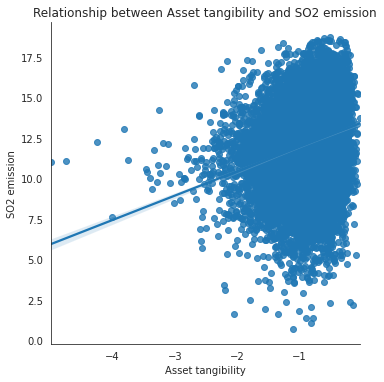

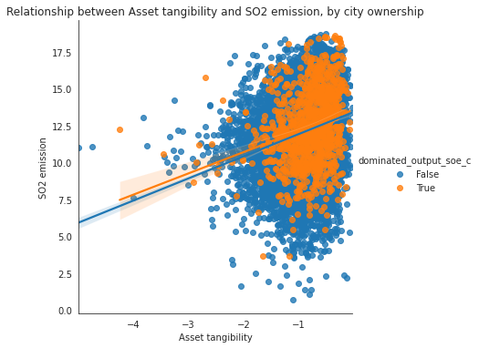

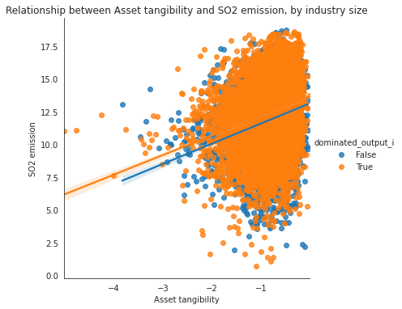

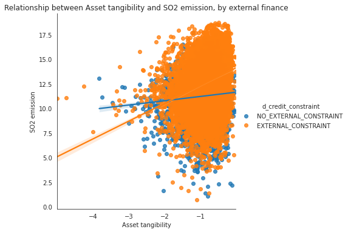

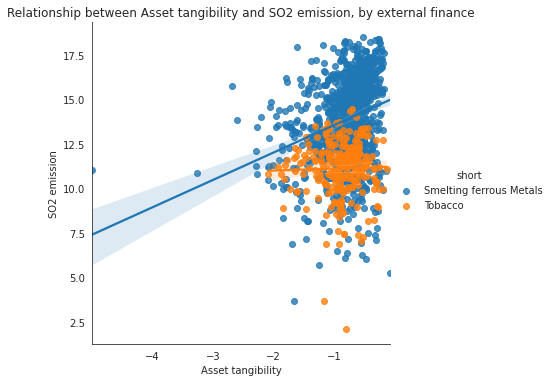

### Cashflow

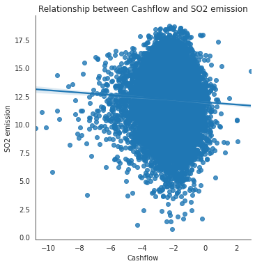

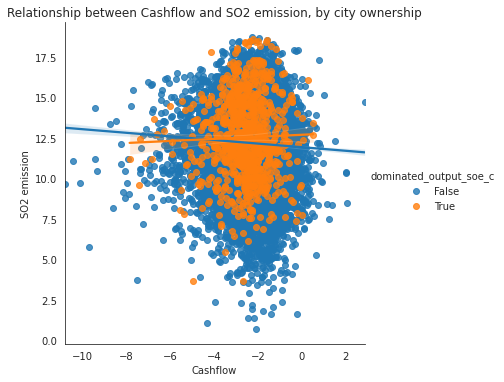

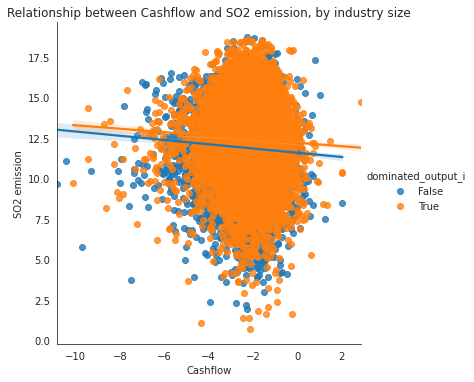

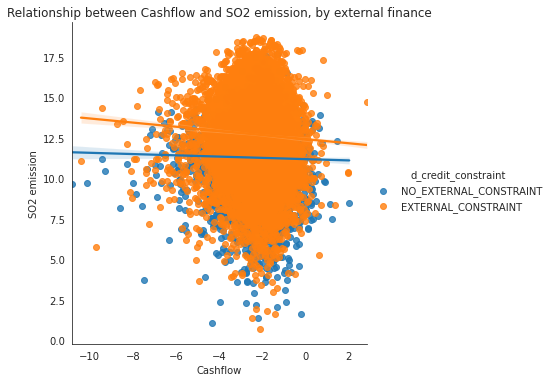

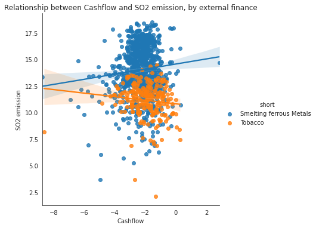

### Current ratio

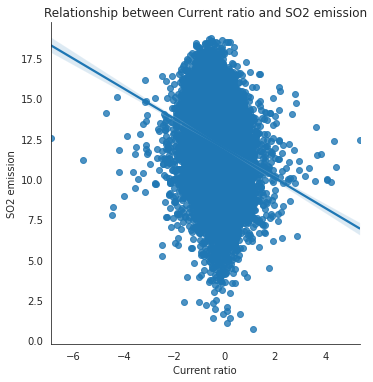

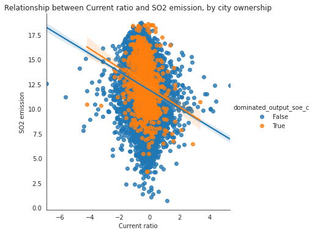

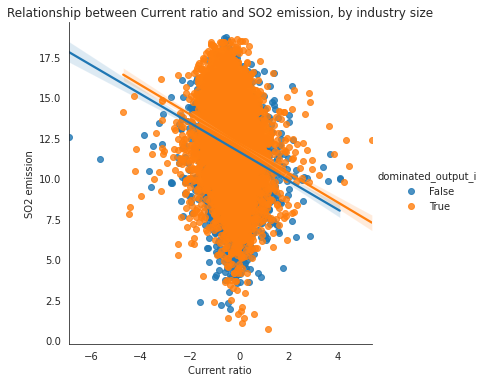

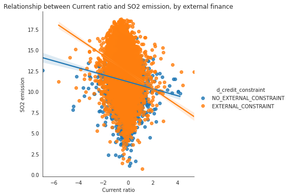

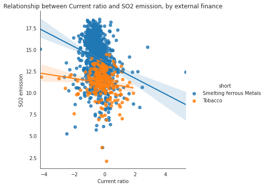

### Liabilities to asset

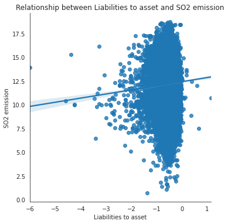

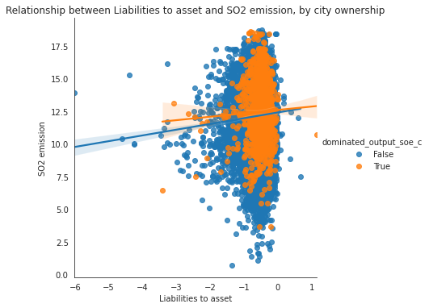

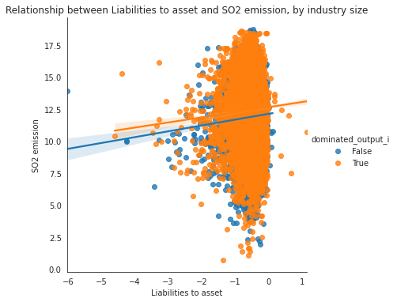

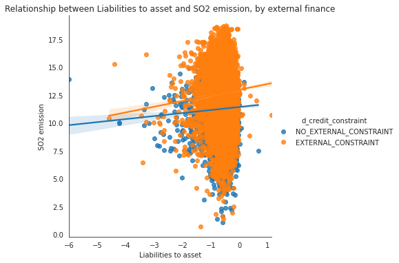

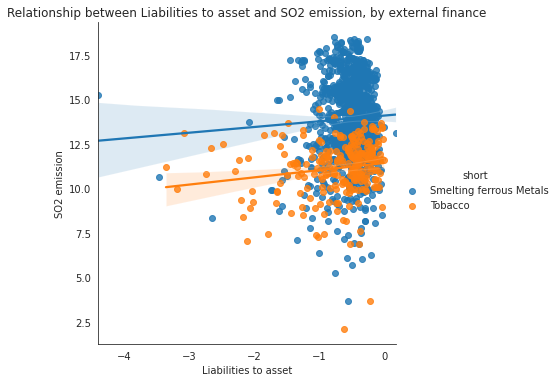

#### RD

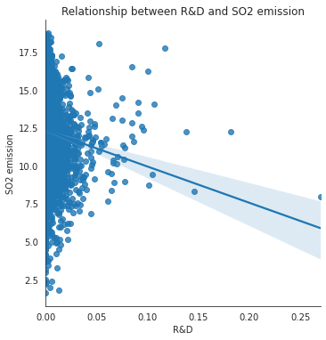

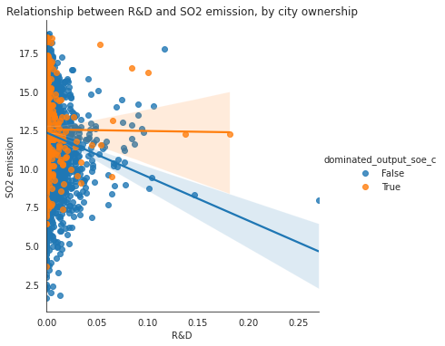

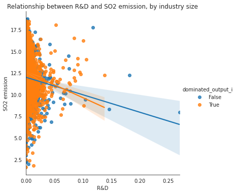

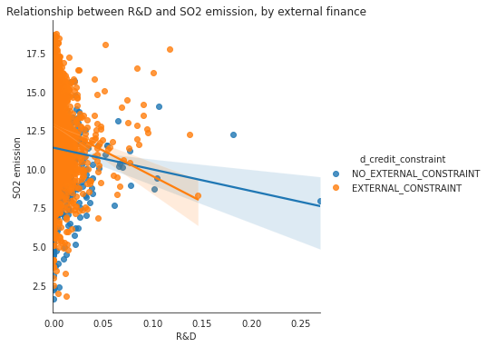

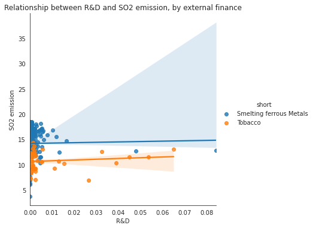

#### TFP

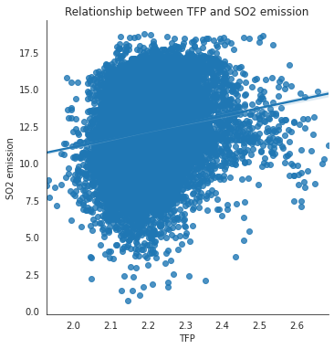

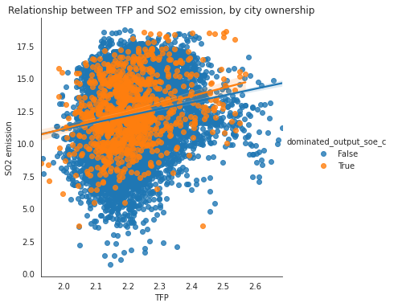

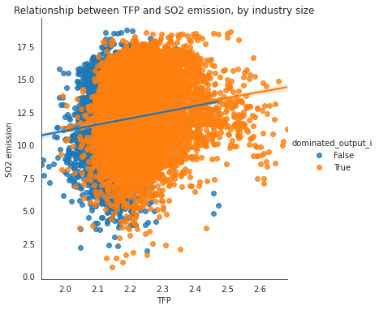

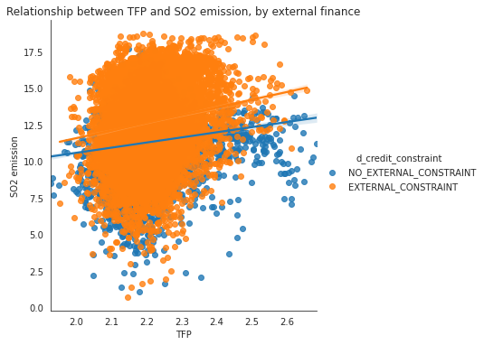

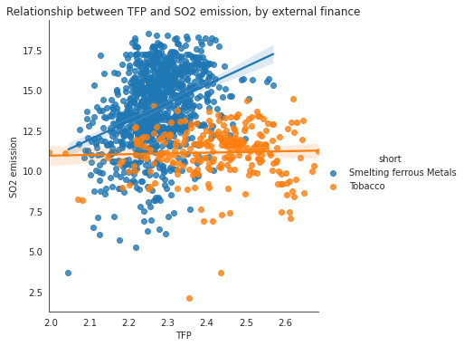

## Side by side

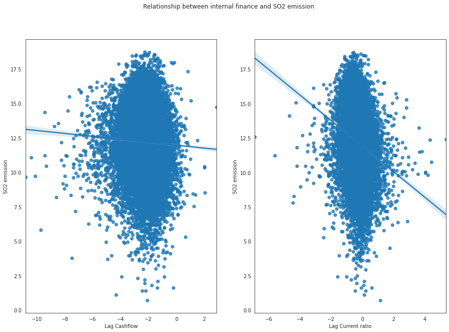